# Sigma Fields

Seoncheol Park

25/11/2019

다음의 책을 참고하였다.

- Probability and Measure, Patrick Billingsley (PB)
- [Probability, Theory and Examples, Rick Durrett](https://services.math.duke.edu/~rtd/PTE/PTE5_011119.pdf) (RD)
- Essential of Probability Theory for Statistician
- Probability Essentials, Jean Jacod and Philip Protter (JP)
- Probability for Statisticians, Galen R. Shorack (GS)
- Probability: A Graduate Course, Allan Gut (AG)
- Analysis, Measure, and Probability: A visual introduction
- Counterexamples in Probability, Jordan M. Stoyanov (JS)

## Probability Triples

(Billingsley 2012)

Let

- $\Omega$: arbitrary space or set of points $\omega$. 확률론에서 $\Omega$ consists of all the possible results or outcomes $\omega$ of an experiment or observation.

**Example 1** For observing the number of heads in $n$ tosses of a coin the space $\Omega$ is $\{0,1,\ldots, n\}$; for describing the complete history of the $n$ tosses $\Omega$ is the space of all $2^{n}$-long sequences of H’s and T’s;

**Example 2** For the infinite sequence of tosses $\Omega$ can be taken as the unit interval as in the Section 1 of (Probability and Measure).

(Gut 2014)

**Probability space** or **probability triple** is ($\Omega, \mathcal{F}, P$), where

- $\Omega$ is the **sample space**
- $\mathcal{F}$ is the collection of **events**
- $P$ is a Probability measure.

(Proschan 2016)

We use the triple $(\Omega, \mathcal{F}, P)$ of probability theory, called the **probability space**, where $\Omega$ is the **sample space** of all possible outcomes of an experiment, $\mathcal{F}$ is the set of events (subsets of $\Omega$) we are allowed to consider, and $P$ is a probability measure.

We also consider more general measure $\mu$, not just probability measures, in which case $(\Omega, \mathcal{F}, \mu)$ is called a **measure space**.

## Three key facts about probability space:

(Proschan 2016)

1. All randomness stems form the selection of $\omega\in\Omega$; once $\omega$ is known, so too are the values of all random variables.
2. A single probability measure $\mathbf{P}$ depermines the distribution of all random variables.
3. Without loss of generality, we can take the sample space $\Omega$ to be the unit interval $[0,1]$ and $\mathbf{P}$ to be “Lebesgue measure”, which in layman’s terms corresponds to drawing $\omega$ at random from $[0,1]$.

앞으로 확률론에서 우리가 가져야 할 질문은 다음과 같다.

Q. Can we define a probability measure that satisfies certain properties and allows us to pick randomly and uniformly from $[0,1]$?

A. **Not** without restricting the events we are allowed to consider.

그렇다면 allowable한 set들을 어떻게 제한할 것인가 하는 문제가 생긴다.

## Field와 $\sigma$-field

(Proschan 2016)

**Definition 1 (Field and sigma-field)** $\Omega$의 subset들의 nonempty collection들에 대해

1. $\mathcal{F}$가 closed under complements and unions of pairs of members일 경우 $\mathcal{F}$를 **field (or algebra)**라고 부른다. 즉
- $\Omega\in\mathcal{F}$,
- $E\in\mathcal{F}$에 대해 $E^{C}\in\mathcal{F}$이고
- $E_1, E_2\in\mathcal{F}$일 경우 (closed under **finite unions**) $E_{1} \cup E_{2} \in \mathcal{F}$일 경우 $\mathcal{F}$는 field가 된다.
2. $\mathcal{F}$가 closed under complements and countable unions일 경우에 $\mathcal{F}$를 $\sigma$**-field** (or $\sigma$**-algebra**)라고 한다. 즉
- $\Omega\in\mathcal{F}$,
- $E\in\mathcal{F}$에 대해 $E^{C}\in\mathcal{F}$이고 (closed under **complementation**) +$E_1, E_2, \ldots \in\mathcal{F}$일 때 $\cup_{i=1}^{\infty}E_i \in \mathcal{F}$일 경우 (closed under **countable unions**) $\mathcal{F}$는 $\sigma$-field가 된다.

*Remark.* Field라는 개념은 algebra라는 말로 대체되기도 한다. 따라서 두 단어를 다 알아두는 것이 좋다.

*Remark.* $\sigma$-field는 field보다 강한 조건이다.

*Remark.* Any $\sigma$-field $\mathcal{F}$ is closed under **countable intersection**s because $\cap_{i=1}^{\infty}E_{i} = (\cup_{i=1}^{\infty}E_{i}^{C})^{C}$ and each $E_i^{C}$ belongs to $\mathcal{F}$.

우리는 $\mathcal{F}$를 $\sigma$-field, a (nonempty) collection of subsets of $\Omega$로 놓는다.

(Stoyanov 2014)

**Example 3 (A class of events which is a field but not a sigma-field)** Let $\Omega =[0, \infty)$ and $\mathcal{F}_{1}$ be the class of all intervals of the type $[a,b)$ or $[a, \infty)$ where $0\leq a < b < \infty$. Denote by $\mathcal{F}_{2}$ the class of all finite sums of intervals of $\mathcal{F}_{1}$. Then $\mathcal{F}_{2}$ the class of all finite sums of intervals of $\mathcal{F}_{1}$. Then $\mathcal{F}_{1}$ is not a field, and $\mathcal{F}_{2}$ is a field but not a $\sigma$-field.

Take arbitrary numbers $a$ and $b$, $0<a<b<\infty$. Then $A=[a,b)\in \mathcal{F}_{1}$. However, $A^{c} = [0,a) \cup [b, \infty)\neq \mathcal{F}_{1}$ and thus $\mathcal{F}_{1}$ is not a field.

It is easy to see that:

1. The finite union of finite sums of intervals (of $\mathcal{F}_{1}$) is again a sum of intervals.
2. The complement of a finite sum of intervals is also a sum of intervals.

This means that $\mathcal{F}_{2}$ is a field.

However, $\mathcal{F}_{2}$ is not a $\sigma$-field because, for example, the set $A_{n}= [0,\frac{1}{n})\in\mathcal{F}_{1}$ for each $n=1,2,\ldots$ and the intersection $\bigcap_{n=1}^{\infty}A_n = \{0 \}$ does not belong to $\mathcal{F}_{1}$.

Let us look at two additional cases.

1. Let $\Omega = \mathbb{R}^{1}$ and $\mathcal{F}$ be the class of all finite sums of intervals of the type $(-\infty, a]$, $(b,c]$ and $(d, \infty)$. Then $\mathcal{F}$ is a field. But the intersection $\bigcap_{n=1}^{\infty}(b-\frac{1}{n}, c]$ is equal to $[b,c]$ which does not belong to $\mathcal{F}$. Hence the field $\mathcal{F}$ is not a $\sigma$-field.
2. Let $\Omega$ be any infinite set and $\mathcal{A}$ the collection of all subsets $A\in \Omega$ such that either $A$ or its complement $A^{C}$ is finite. Then it is easy to see that $\mathcal{A}$ is a field but not a $\sigma$-field.

(Stoyanov 2014)

**Definition 2 (Semi-field)** Let $\Omega$ be an arbitrary set. A non-empty class $\mathcal{S}$ of subsets of $\Omega$ is called a **semi-field** if

1. $\Omega \in \mathcal{S}$, $\emptyset \in \mathcal{S}$,
2. $\mathcal{S}$ is closed under the formation of finite intersections,
3. the complement of any set in $\mathcal{S}$ is a finite sum of disjoint sets of $\mathcal{S}$.

It is easy to see that any field of subsets of $\Omega$ is also a semi-field. However, the following simple examples show that the converse is not true.

**Example 4 (A class of events which is a semi-field but not a field)** 1. Let $\Omega = [-\infty, \infty)$ and $\mathcal{S}_{1}$ contain $\Omega$, $\{ \infty\}$ and all intervals of the type $[a,b)$ where $-\infty < a \leq b \leq \infty$. Then $\emptyset \in \mathcal{S}_{1}$, $\Omega \in \mathcal{S}_{1}$, $[a_1, b_1) \cap [a_2, b_2) = [a_1, \vee a_2, b_1 \wedge b_2) \in \mathcal{S}_1$, and $[a,b)^{C} = [-\infty, a) \cup [b,\infty)$. So $\mathcal{S}_{1}$ is a semi-field. Obviously $\mathcal{S}_{1}$, is not a field.

2. Take $\Omega = \mathbb{R}^{1}$ and denote by $\mathcal{S}_{2}$ the class of all subsets of the for $A\cap B$ where $A$ is a closed and $B$ is an open set in $\Omega$. Then again, $\mathcal{S}_{2}$ is a semi-field but not a field.

(Proschan 2016)

**Example 5 (Trivial and total sigma-fields)** For any sample space $\Omega$,

- the smallest $\sigma$-field is the **trivial** $\sigma$-field $t(\Omega) = \{ \emptyset, \Omega\}$, and
- the largest $\sigma$-field is the **total** $\sigma$-field (also called the power $\sigma$-field) $T(\Omega) = \{\text{all subsets of } \Omega\}$.

우리는 어떤 이벤트 $E$가 $E\in \mathcal{F}$일 때만 (확률을) 결정할 수 있다고 가정했을 때 trivial $\sigma$-field는 전체사건과 공집합만을 표현할 수 있다는 점에서 쓸모 있는 $\sigma$-field가 되지 못한다.

한편 total $\sigma$-field의 경우에는 $\Omega$에 들어가 있는 모든 부분집합들 $E\subset \Omega$와 그것의 여집합들의 확률을 전부 만들어 낼 수 있다. 그러나 $T(\Omega)$의 문제점은 모든 이벤트 $E\in\mathcal{F}$ 들에게 바람직한 성질을 갖도록 하는 확률측도를 만들어낼 수 없다는 점이다.

즉 우리는 $\mathcal{F}$가 크면 좋지만, 바람직한 성질을 갖도록 어느 정도 제한을 두어야 한다는 결론을 얻는다.

뒷장에서 쓸 내용을 위해 $\sigma$-field들의 intersection 또한 $\sigma$-field가 됨을 짚고 넘어가자.

**Proposition 1 (Intersections of sigma-fields are sigma-fields)** The intersection $\cap_{t} \mathcal{F}_t$ of any collection of $\sigma$-fields is a $\sigma$-field.

*Proof.* First note that $\mathcal{F}$ is nonempty because $\emptyset \in \mathcal{F}_{t}$ and $\Omega\in \mathcal{F}_{t}$ for each $t$, and therefore $\emptyset$ and $\Omega$ belong to $\mathcal{F} = \cap_{t} \mathcal{F}_{t}$. Also, if $E\in\mathcal{F}$, then $E$ belongs to each $\mathcal{F}_{t}$. Thus $E^{C}$ belongs to each $\mathcal{F}_{t}$, and therefore to $\mathcal{F} = \cap_{t} \mathcal{F}_{t}$. Similarly, if $E_1, E_2, \ldots$ belong to each $\mathcal{F}_{t}$, then $E= \cup_{i=1}^{\infty}E_{i}$ also belongs to each $\mathcal{F}_{t}$, so $E$ belongs to $\mathcal{F} = \cap_{t} \mathcal{F}_{t}$. It follows that $\mathcal{F}$ is a $\sigma$-field.

## ($\sigma$-field) Generators

(Gut 2014) 2.3절

어떤 $\Omega$에 대해서도 Total $\sigma$-field가 항상 존재하기 때문에 $\mathcal{A}$를 $\Omega$의 subset들의 collection이라고 할 경우 $\mathcal{A}$를 포함하는 $\sigma$-field는 항상 존재하게 된다. 또한 Proposition 1에 의해 $\sigma$-field들의 intersection 또한 $\sigma$-field가 될 것이므로 $\mathcal{A}$를 포함하는 **가장 작은** $\sigma$-field 또한 존재하게 된다. 즉
$$\mathcal{F}^{*} =\{ \sigma\text{-fields } \supset \mathcal{A} \}$$
이라고 할 때 $\mathcal{A}$를 포함하는 가장 작은 $\sigma$-field는 다음과 같다.
$$\bigcap_{\mathcal{G}\in \mathcal{F}^{*}}\mathcal{G}.$$
그리고 우리가 $\mathcal{A}$를 포함하는 모든 $\sigma$-field를 intersection했기 때문에 이것은 unique하다.

**Definition 3 (Sigma-algebra, generated by)** $\mathcal{A}$를 $\Omega$의 subset들의 collection이라고 하자. $\mathcal{A}$를 포함하는 가장 작은 $\sigma$-field를 $\sigma(\mathcal{A})$라고 할 때 이것을 $\sigma$-**algebra generated by** $\mathcal{A}$라고 부른다.

**Exercise 1** 다음을 증명해보자.

1. 만약 $\mathcal{A}=A$, 즉 $\mathcal{A}$가 single set일 경우에 $\sigma(\mathcal{A})= \sigma(A) = \{\emptyset, A, A^{C}, \Omega\}$이다.
2. 만약 $\mathcal{A}$가 $\sigma$-field이면 $\sigma(\mathcal{A})=\mathcal{A}$.

## $\sigma$-fields when $\Omega=\mathbb{R}$

(Proschan 2016)

이제 $\Omega$가 uncountalbe set $\mathbb{R}$ (또는 interval)일 때의 $\sigma$-field에 대해 생각해보자. 여기서도 가장 유용한 $\sigma$-field는 singleton $\omega$들을 포함하는 $\sigma$-field일 것이다.

**Exercise 2** Prove that the collection of countable and co=countable sets is itself a $\sigma$-field.

결국 우리는 $\mathbb{R}$과 같은 uncountable set에서 유용한 smallest $\sigma$-field를 다시 찾아봐야 한다. 우리가 원하는 것은 $\mathcal{F}$에 모든 interval들이 포함되도록 하는 것이다. 그러나 $\mathcal{F}$가 너무 커지면 확률을 정의할 수 없는 이상한 현상들이 일어남을 명심하자.

**Example 6 (Vary inmportant field)** If $\Omega = \mathbb{R}$, the collection $\mathcal{F}_{0}$ of finite unions of disjoint sets of the form $(a,b]$, $(-\infty, a]$, or $(b,\infty)$ is a field, but not a $\sigma$-field. It generate $\sigma(\text{intervals})$.

**Exercise 3** Prove the above.

(Proschan 2016)

$\sigma(\text{intervals})$를 찾는 여정을 계속해보자. 다음과 같이 interval들을 포함하는 모든 $\sigma$-field들의 collection $\{\mathcal{F}_{t}\}_{t\in T}$를 생각해보자. 우리는 total $\sigma$-field $T(\mathbb{R})$이 모든 line들의 subset을 포함할 것이기에 적어도 하나의 $\mathcal{F}_{t}$가 존재할 것임을 안다.

이제 $\mathcal{F} = \cap_{t} \mathcal{F}$라고 두면 $\mathcal{F} = \sigma(\text{intervals})$임을 보이면 된다. 한편 interval들을 포함하는 모든 $\sigma$-field는 $\mathcal{F}$에 포함되어 있기 때문에, 우리는 $\mathcal{F}$가 $\sigma$-field임을 보이기만 하면 된다. 그런데 Proposition 1에 의해 $\mathcal{F}$는 $\sigma$-field가 될 것이다.

**Definition 4 (1-dimensional Borel sigma-field)** The smallest $\sigma$-field containing the intervals of $\mathbb{R}$, namely the intersection of all $\sigma$-fields containing the intervals, is called the **Borel** $\sigma$**-field** and denotes $\mathcal{B}$ or $\mathcal{B}^{1}$. The sets in $\mathcal{B}$ are called Borel sets. The Borel sets of $\mathbb{R}$ that are subsets of $[0,1]$ are denoted $\mathcal{B}_{[0,1]}$.

*Remark.* Borel $\sigma$-field는 매우 넓은 개념이다. 단지 interval들만 포함하는 것이 아니고 다음의 것들도 포함한다.

1. Countable unions of intervals, and therefore all open sets
2. All closes sets by part 1 and that complements of sets in $\mathcal{B}$ are in $\mathcal{B}$
3. The rational numbers by part 2 because each rational $r$ is a closed set (it is easy to see that its complement is open), and the set of rational numbers is a countable union of these closed sets
4. The irrational numbers, being the complement of the Borel set of rational numbers

Borel $\sigma$-field의 설명이 추상적인데, 좀 더 자세한 설명은 Billingsley (2012) 의 “constructing sigma-fields” 부분을 참고하길 바란다.

참고로 1번 항이 성립하는 이유는 다음의 Proposition 때문이다.

(Proschan 2016) Proposition A.15

**Proposition 2 (Characterization of open sets in R)** A set $A\in\mathbb{R}$ is open if and only if it is the union of a countable collection of disjoint open intervals.

## $\sigma$-fields when $\Omega = \mathbb{R}^{k}$

우선 $k=2$인 경우를 생각해보자. 이것은 1차원에서 적용했던 아이디어를 그대로 2차원에 확장하면 된다. Let $\mathbb{R}^{2}$ be the product set $\{(x_1, x_2), x_1 \in \mathbb{R}, x_2 \in \mathbb{R}\}$. 그리고 $I_1 \times I_2 = \{ (x_1, x_2): x_1 \in I_1, x_2 \in I_2 \}$와 같은 사각형들의 collection $\mathcal{A}$를 생각해보자. 이 때 $I_1$, $I_2$들은 (open, closed, or half open, finite or infinite) interval들이다.

그리나 이 경우 $\mathcal{A}$는 $\sigma$-field도, field도 아니게 된다. 예를 들면 $[(0,1)\times (0,1)]^{C}\notin \mathcal{A}$이다. 그럼에도 불구하고, $\mathcal{A}$를 포함하는 $\sigma$-field $\sigma(\mathcal{A})$를 만들 수 있다.

**Definition 5 (2-dimensional Borel sigma-field)** The smallest $\sigma$-field containing the set $\mathcal{A}$ of all possible rectangles is called the **2-dimensional Borel** $\sigma$**-field**, and denoted $\mathcal{B}^{2}$. Sets in $\mathcal{B}^{2}$ are called **2-dimensional Borel sets**.

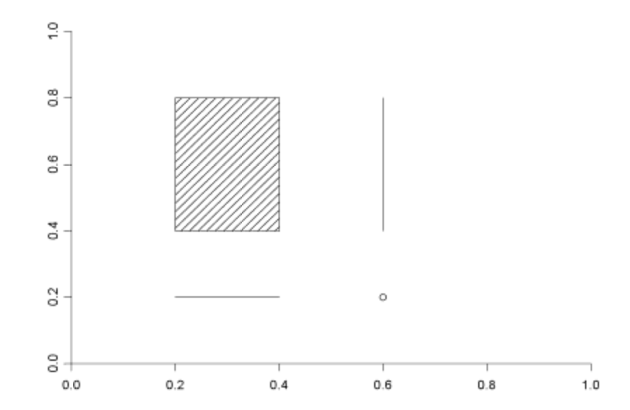

2차원 보렐 집합의 한 가지 예. 이것은 $B_{1}\times B_{2}$로 이루어져 있으며 이 때 $B_{1} = \{ (0.2, 0.4)\cup 0.6\}$, $B_2 = \{0.2 \cup (0.4, 0.8) \}$로 이루어져 있다.

**Proposition 3 (2차원 Borel sigma-field는 1차원 보렐 집합들을 포함함)** $\mathcal{B}^{2}$는 $B_{1}$, $B_{2}$가 1차원 보렐 집합이라고 할 때 $B_{1} \times B_{2}$ 형태의 모든 집합들을 포함하고 있다.

*Proof.* (Proschan 2016)

다음의 두 단계를 보이면 된다.

1. 모든 구간 $I$에 대해 $I\times B\in\mathcal{B}^{2}$ for every $B\in\mathcal{B}^{1}$.
2. Let $\mathcal{C} = \{ C \in \mathcal{B}^{1}: C\times B \in \mathcal{B}^{2} for all B \in \mathcal{B}^{1}\}$, and note that $\mathcal{C}$ contains all intervals by part 1. We show that $\mathcal{C}$ contains $\mathcal{B}^{1}$.

For given interval $I$, let $\mathcal{B}^{1}$ be the collection of one-dimensional Borel sets $B$ such that $I \times B \in \mathcal{B}^{2}$. Then $\mathcal{B}_{I}$ contains all intervals because $\mathcal{B}^{2}$ contains products of intervals. Also $\mathcal{B}_{I}$ is a $\sigma$-field because $\mathcal{B}^{2}$ is. For instance, $\mathcal{B}_{I}$ is closed under countable unions because if $B_1, B_2, \ldots\in \mathcal{B}_{I}$, then $I\times \cup_{i}B_{i} = \cup_{i}(I\times B_{i})\in\mathcal{B}^{2}$ because each $I\times B_{i}\in \mathcal{B}^{2}$. Also, the following argument shows that $\mathcal{B}_{I}$ is closed under complementation. If $B_{i}\in\mathcal{B}_{i}$, then
$$\begin{equation}
I\times B_{i}^{C} = (I \times B_{i})^{C} \cap (I \times R).
\tag{1}
\end{equation}$$

By assumption, $I\times B_{i} \in \mathcal{B}^{2}$, so $(I \times B_{i})^{C} \in \mathcal{B}^{2}$. Also, $I\times R \in \mathbb{R}^{2}$ because $\mathcal{B}^{2}$ contains all products of intervals, and $I\times R$ is a product of intervals. We have shown that both members of the intersection in (1) are in $\mathcal{B}^{2}$, so $I\times B_{i}^{C}$ is in $\mathcal{B}^{2}$ because $\mathcal{B}^{2}$ is a $\sigma$-field. This means that $B_{i}^{C} \in \mathcal{B}_{I}$. We have shown that $\mathcal{B}_{I}$ is a $\sigma$-field containing all intervals, so $\mathcal{B}_{I}$ contains the smallest $\sigma$-field containing the intervals, namely $\mathcal{B}^{1}$. Thus, $I\times B \in \mathcal{B}^{2}$ for each $B\in \mathcal{B}^{1}$, which complets the proof or step 1.

Next, fix $B\in\mathcal{B}^{1}$ and define $\mathcal{C}$ to be the collection of one-dimensional Borel sets $C$ such that $C\times B\in\mathcal{B}^{2}$. By step 1, $\mathcal{C}$ contains all intervals. An argument similar to that used in step 1 shows that $\mathcal{C}$ is a $\sigma$-field. Because $\mathcal{C}$ is a $\sigma$-field containing all intervals, $\mathcal{C}$ contains $\mathcal{B}^{1}$. This completes the proof of step 2.

2차원 보렐 집합 또한 매우 풍부한 class이다. 그리고 이것은 단순히 1차원 보렐 집합들의 direct product들만 포함하는 것이 아니다. 예를 들면 $C= \{(x,y)\in (0,1) \times (0,1): x+y < 1\}$은 2차원 보렐 집합이지만 direct product는 아니다. (Proschan 2016)

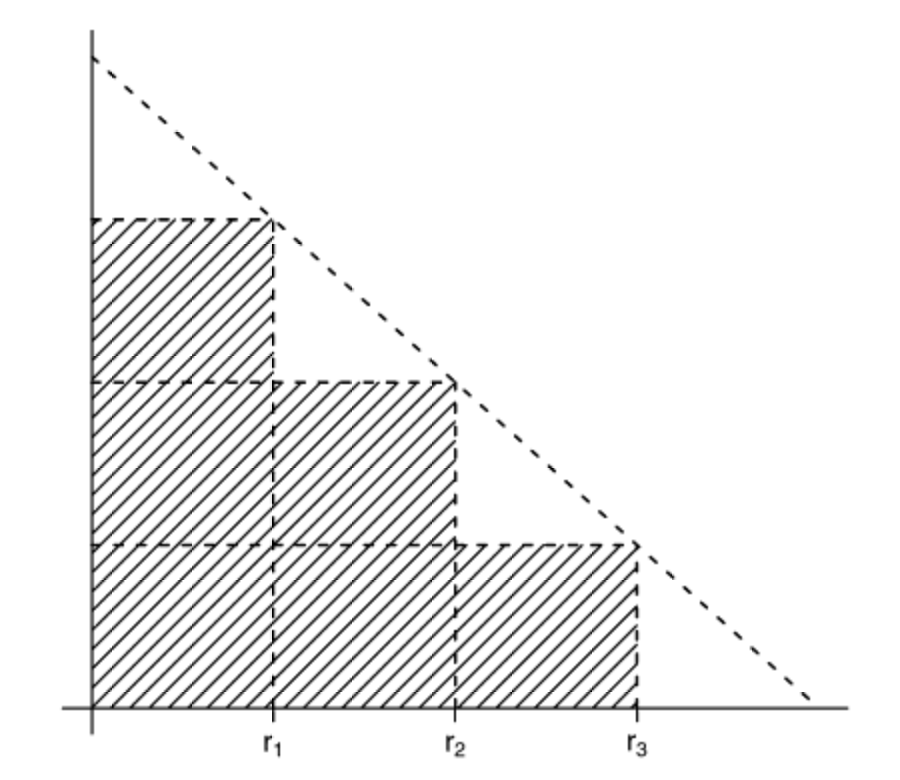

$r=1/4, 1/2$ 그리고 $3/4$일 때의 union $\cup_{r} (0,r)\times (0,1-r)$. 모든 $r\in (0,1)$의 유리수에 대해 union을 취하면 entire triangle $\{ (x,y)\in (0,1)\times (0,1): y < 1-x \}$를 얻을 수 있다.

$C$가 정말 2차원 보렐 집합인지 보려면, 우선 $C=\cup_{r}(0,r)\times (0, 1-r)$ (이 때 $r$은 $(0,1)$에 있는 유리수)로 나타낼 수 있음을 알아야 한다. $C$는 사각형들의 countable union이기 때문에, $\mathcal{B}^{2}$가 된다.

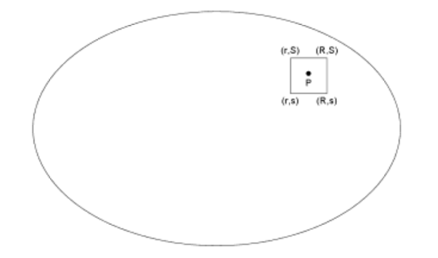

열린 집합의 임의의 점은 $(r,R)\times (s,S)$ ($r, R, s, S$는 유리수)인 사각형 안에 반드시 들어가게 된다.

**Proposition 4 (2-dimensional Borel sigma-field contains all 2-dimensional open and clased sets)** $\mathcal{B}^{2}$ contains all open and closed sets in $\mathbb{R}^{2}$.

아마 $\mathcal{B}^{2}$에 들어가지 않는 보렐 집합을 찾는 것이 더 어려울 것이다. ((Stoyanov 2014) 1.6)

$k$차원 보렐 집합에 대해서도 같은 얘기를 할 수 있다.

$k$차원 보렐 집합이 우리가 관심 있어 하는 거의 모든 집합들을 포함하지만 확률론에서는 가끔 $k$-차원 르베그 집합과 같이 더 큰 $\sigma$-field를 사용하기도 한다.

Billingsley, Patrick. 2012. *Probability and Measure Anniv*. 3rd ed. John Wiley & Sons. https://www.ebook.de/de/product/15578575/billingsley_probability_and_measure_anniv.html.

Gut, Allan. 2014. *Probability: A Graduate Course*. 2nd ed. Springer New York. https://www.ebook.de/de/product/23277813/allan_gut_probability_a_graduate_course.html.

Proschan, Michael A. 2016. *Essentials of Probability Theory for Statisticians*. CRC Press. https://www.ebook.de/de/product/25453130/michael_a_proschan_essentials_of_probability_theory_for_statisticians.html.

Rick (Duke University, North Carolina) Durrett. 2019. *Probability: Theory and Examples*. 5th ed. Cambridge University Press. https://www.ebook.de/de/product/34699864/rick_duke_university_north_carolina_durrett_probability.html.

Stoyanov, Jordan M. 2014. *Counterexamples in Probability: Third Edition*. 3rd ed. DOVER PUBN INC. https://www.ebook.de/de/product/19654789/jordan_m_stoyanov_counterexamples_in_probability_third_edition.html.